# Using ExEmPLAR FR

Nyssa Tucker

2023-01-24

# Motivation

The purpose of this document is to assist with  
_1 articulating the application of [ExEmPLAR](https://www.exemplar.mml.unc.edu/),  
_2 noting steps for making good questions, and  
_3 demonstrating example use case.

ExEmPLAR is developed by [Jon-Michael Beasley](https://molecularmodelinglab.github.io/members/jon_michael_beasley.html) while researching towards a PhD at UNC Chapel Hill.

## FIX THESE THINGS IN DOCUMENT

–> exemplar citation?  
–> put in working directory and route to my local exemplar github to save examples  
–> another couple eda table  
–> use case expand to the degree-weighted-path counts and  
–> use case expand to use pubmed comentions and  
–> use case expand to use pca function  
–> how actually stepwise get to run exemplar locally

## Why use ExEmPLAR

The purpose of this tool is to act as an interface with knowledge graphs tools in building queries and returning results which can be manipulated, annotated, and exported for further evaluation.

Features in this tool also enable query caching and transfer into the [Neo4j Robokop](http://robokopkg.renci.org/browser/) environment.

[figure not shown]

Exemplar landing page at https://www.exemplar.mml.unc.edu/

## How to make a query

Start with writing down a question. Consider how to frame your question into a direction [i.e. chemical leads to effect].

### Node name resolver

Identify your start and ending points. ExEmPLAR has built in term checking functions, but your question may benefit from some built in specificity [i.e. heart disease could be narrowed down more specifically to instances encoded as chemically-induced-cardiotoxicity]. Check out your terms using [renci name resolver](https://name-resolution-sri.renci.org/docs) to find the specific ID you need.

### Run ExEmPLAR locally

ExEmPLAR can be run locally by first forking the associated [GitHub](https://github.com/beasleyjonm/AOP-COP-Path-Extractor). Integrate it with your local environment using for example GitHub Desktop, and start the “dash_app.py” located within the repo “AOP-COP-Path-Extractor” by running python “wdir\GitHub\AOP-COP-Path-Extractor\dash_app.py”

## Use case

### Cardio tox and Flame Retardants

To address the question of an example relationship between flame retardants and cardiovascular outcomes, I queried Tetrabromobisphenol A ; 1,2,5,6,9,10-Hexabromocyclododecane ; & Triethyl phosphate towards the cardiovascular toxicity endpoints: MONDO:0005267, UMLS:C0876994, and cardiovascular disorder. As characterized below.

#### Exploratory data analysis

##### Load and characterize

```r
q1_pickle <- "C:/Users/Nyssa/Documents/GitHub/cautious-giggle/mml/20230124_mml_exemplar_ex.pickle"
df <- as_tibble(read.csv("C:/Users/Nyssa/Documents/GitHub/cautious-giggle/mml/20230124_mml_exemplar_use_ex_result.csv"))

kable(head(df))
```

| ï..path | node0…biolink.ChemicalEntity. | edge0 | node1..wildcard | edge1 | node2..wildcard | edge2 | node3…biolink.DiseaseOrPhenotypicFeature. |
| --- | --- | --- | --- | --- | --- | --- | --- |
| P1 | 1,2,5,6,9,10-Hexabromocyclododecane | contributes to | cardiovascular disorder | subclass of | autosomal recessive limb-girdle muscular dystrophy type 2W | subclass of | heart disorder |
| P1 | 1,2,5,6,9,10-Hexabromocyclododecane | contributes to | cardiovascular disorder | subclass of | chronic pulmonary heart disease | subclass of | heart disorder |
| P1 | 1,2,5,6,9,10-Hexabromocyclododecane | contributes to | cardiovascular disorder | subclass of | aortic valve disease 3 | subclass of | heart disorder |
| P1 | 1,2,5,6,9,10-Hexabromocyclododecane | contributes to | cardiovascular disorder | subclass of | anterior deviation infundibular septum | subclass of | heart disorder |
| P1 | 1,2,5,6,9,10-Hexabromocyclododecane | contributes to | cardiovascular disorder | subclass of | intermediate coronary syndrome | subclass of | heart disorder |
| P1 | 1,2,5,6,9,10-Hexabromocyclododecane | contributes to | cardiac rhythm disease | correlated with | intermediate coronary syndrome | subclass of | heart disorder |

There are `317` results from this query. Results are split as seen below with no representation for Triethyl phosphate.

```
##
##
## |Var1                                | Freq|
## |:-----------------------------------|----:|
## |1,2,5,6,9,10-Hexabromocyclododecane |  227|
## |Tetrabromobisphenol A               |   90|
```

This query is not great in my opinion because the majority response is a direct link to cardiovascular disease:

```
##
##
## |Var1                    | correlated with| genetic association| has phenotype| subclass of|
## |:-----------------------|---------------:|-------------------:|-------------:|-----------:|
## |cardiovascular disorder |              12|                   0|             0|         149|
## |cardiac rhythm disease  |              14|                   0|             2|          14|
## |eye disorder            |               1|                   0|             0|          11|
## |immune system disorder  |               0|                   0|             0|           7|
## |kidney disorder         |               4|                   0|             0|           4|
## |Cardiomegaly            |               7|                   0|             0|           1|
```

##### Heatmap

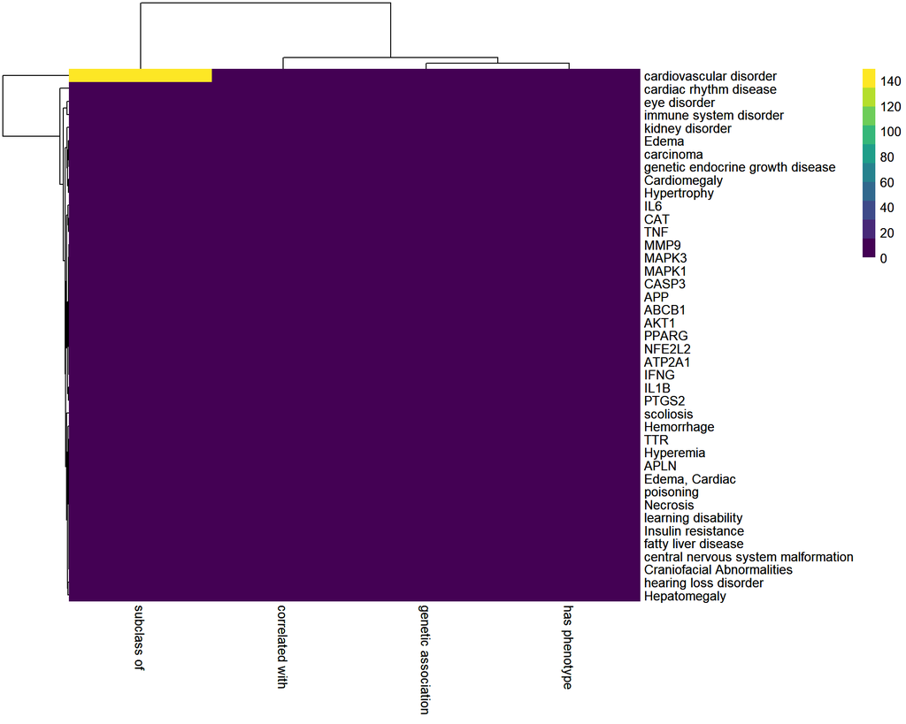

scald

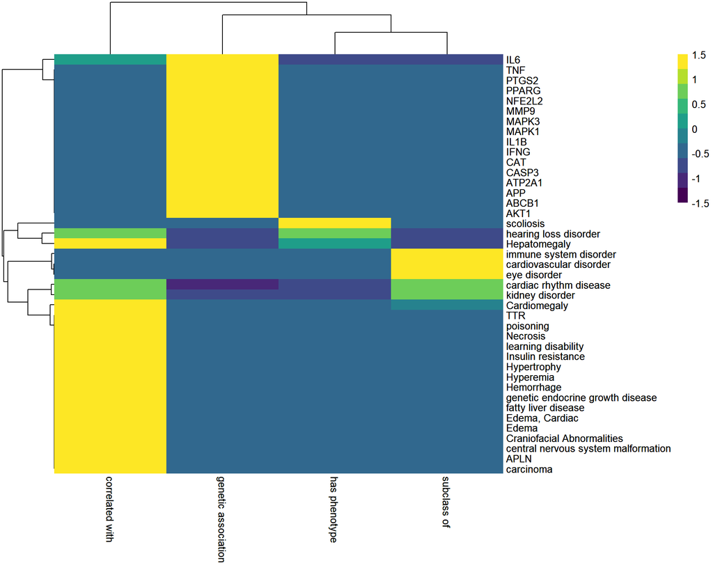

| Var2 | affects | contributes to | decreases response to |
| --- | --- | --- | --- |
| correlated with | 6 | 77 | 0 |
| genetic association | 36 | 0 | 2 |
| has phenotype | 0 | 10 | 0 |
| subclass of | 0 | 186 | 0 |

| Var1 | subclass of |
| --- | --- |
| correlated with | 83 |
| genetic association | 38 |
| has phenotype | 10 |
| subclass of | 186 |

##### Narrow results

The above results are flooded with disease associations, namely cardiovascular disorder. Let’s narrow them down.

###### Parse existing query

First filter out first cardiovascular disorder itself and get frequency counts of the remainder. Realize that there are many other disease associations and then limit table to those with seven or fewer characters, reasoning that the gene/protein names would likely be the remainder.

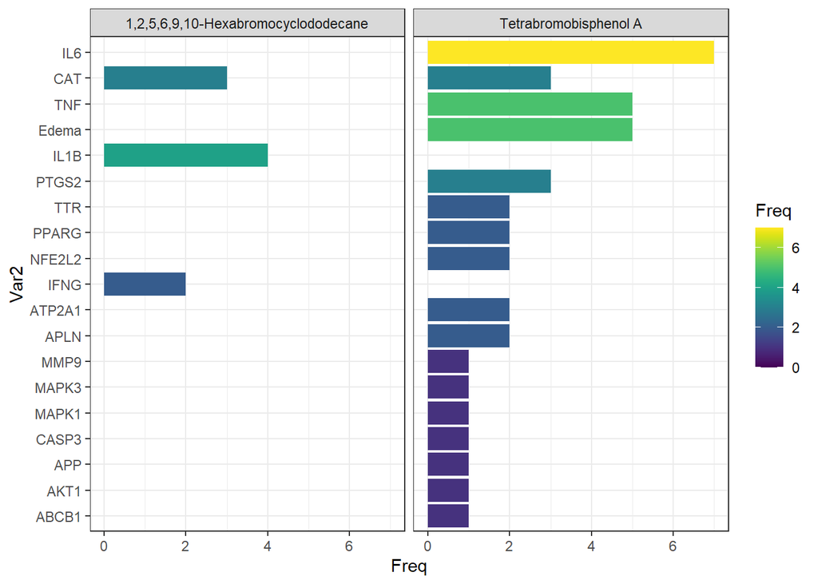

```
##  [1] ABCB1  AKT1   APLN   APP    ATP2A1 CASP3  CAT    Edema  IFNG   IL1B
## [11] IL6    MAPK1  MAPK3  MMP9   NFE2L2 PPARG  PTGS2  TNF    TTR
## 19 Levels: ABCB1 AKT1 APLN APP ATP2A1 CASP3 CAT Edema IFNG IL1B IL6 ... TTR
```

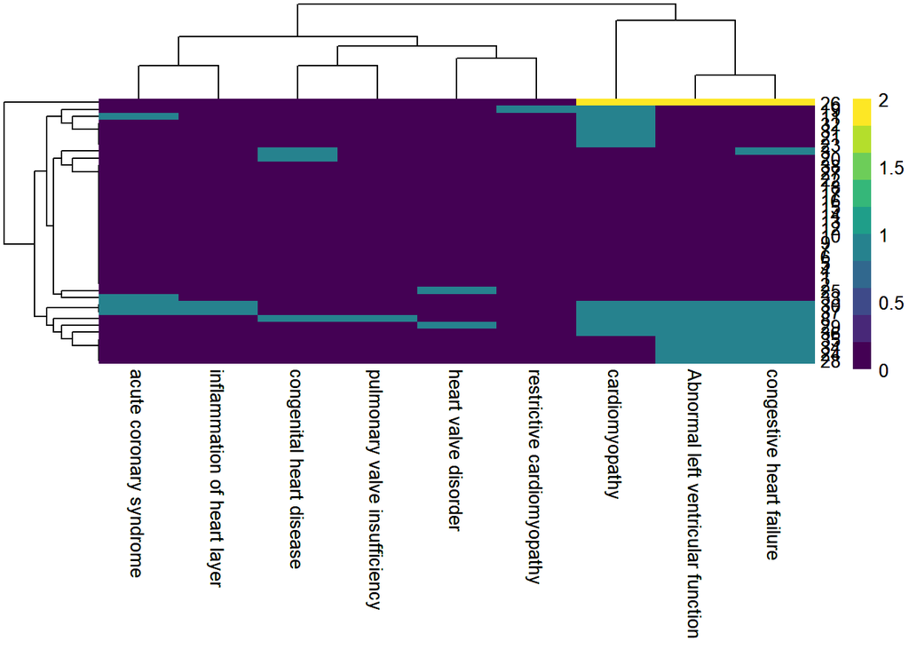

Above amounts to a list of implicated genes. Adjusting the initial query by requiring an intermediary node to result in terms of gene or gene product supplies the relevant information without overloading on associations.

###### New query - gene hop 1

Below is a query with two paths of two hops each. In the first query gene or gene product is required in the first hop, whereas the second query has the second hop requiring gene or gene product.

```r
df <- as_tibble(read_csv(paste0(wdir,"20230126_mml_exemplar_use_ex_q2.csv")))
```

Hop 1 results:

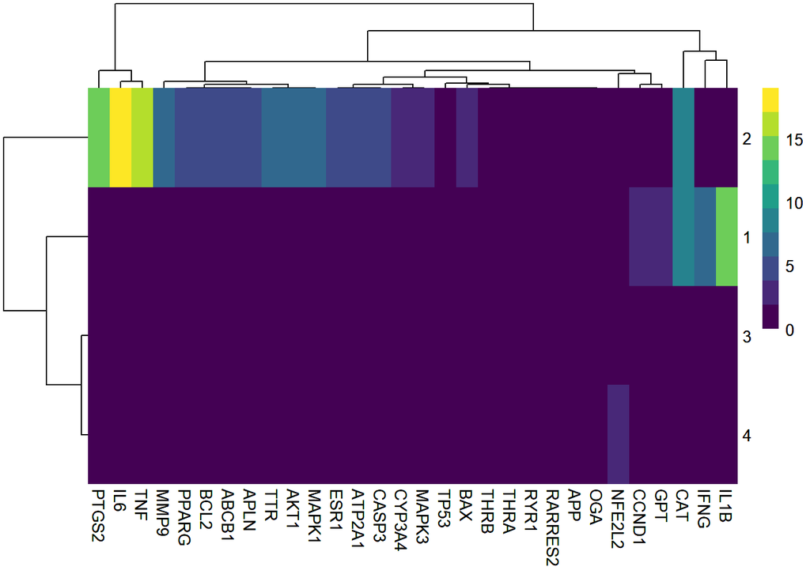

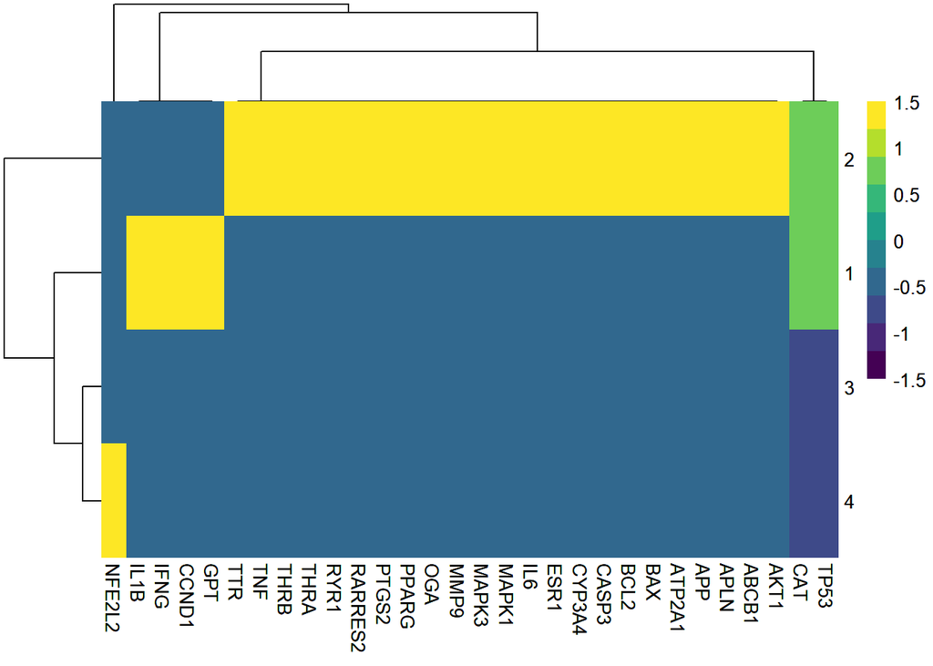

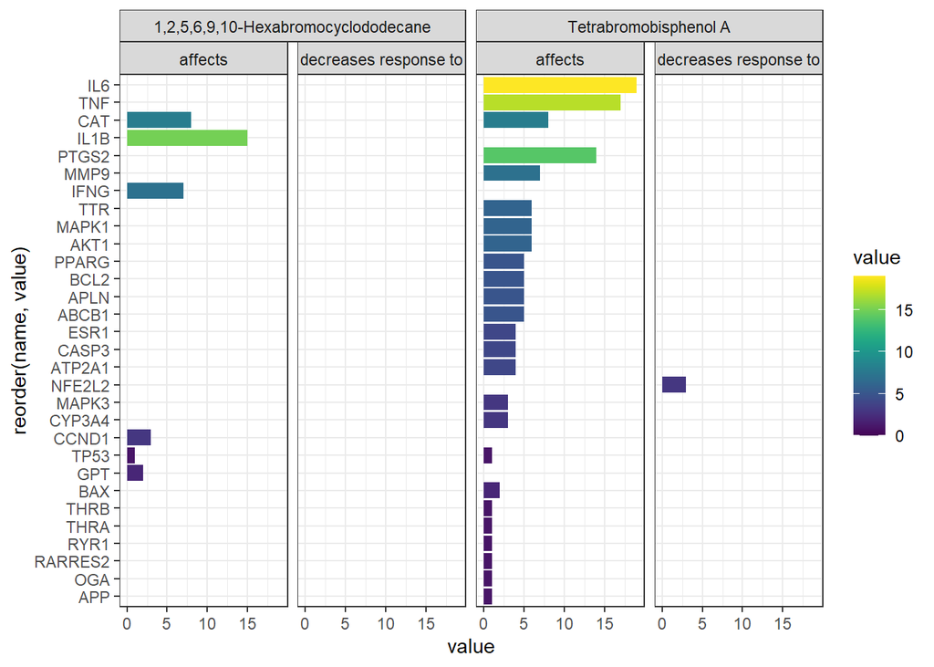

```
##  [1] "ABCB1"   "AKT1"    "APLN"    "APP"     "ATP2A1"  "BAX"     "BCL2"
##  [8] "CASP3"   "CAT"     "CCND1"   "CYP3A4"  "ESR1"    "GPT"     "IFNG"
## [15] "IL1B"    "IL6"     "MAPK1"   "MAPK3"   "MMP9"    "NFE2L2"  "OGA"
## [22] "PPARG"   "PTGS2"   "RARRES2" "RYR1"    "THRA"    "THRB"    "TNF"
## [29] "TP53"    "TTR"
```

###### New query - gene hop 2

Hop 2

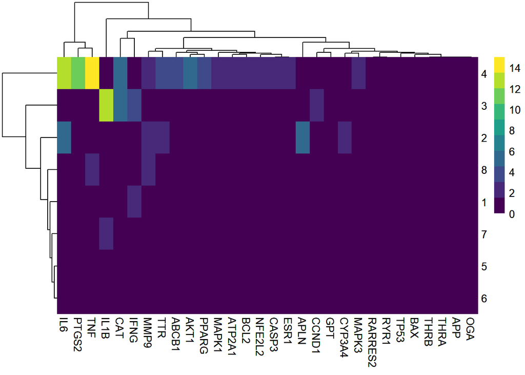

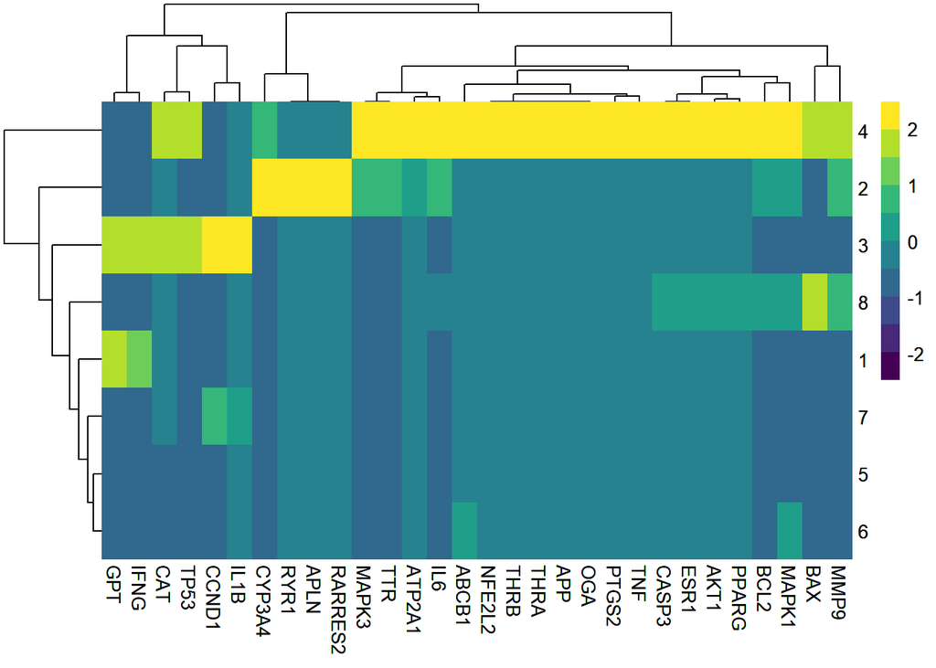

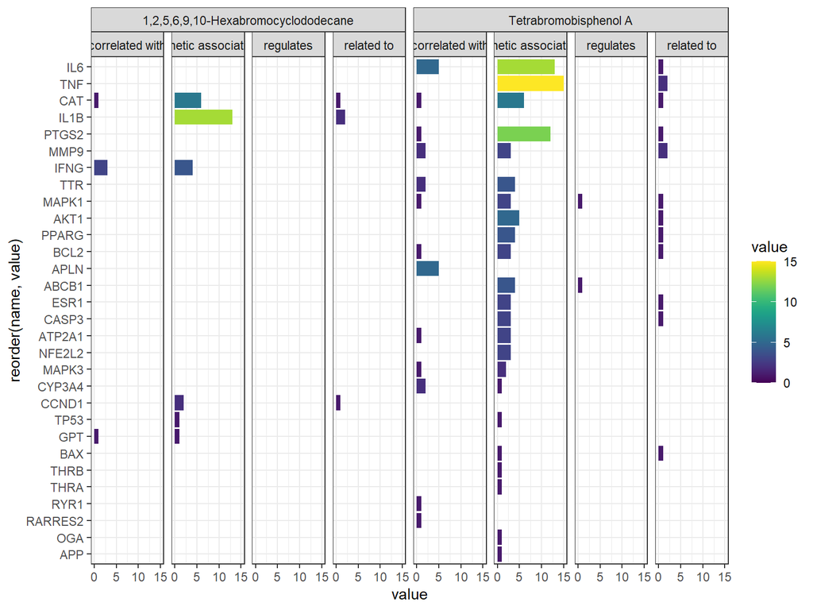

```
##  [1] "ABCB1"   "AKT1"    "APLN"    "APP"     "ATP2A1"  "BAX"     "BCL2"
##  [8] "CASP3"   "CAT"     "CCND1"   "CYP3A4"  "ESR1"    "GPT"     "IFNG"
## [15] "IL1B"    "IL6"     "MAPK1"   "MAPK3"   "MMP9"    "NFE2L2"  "OGA"
## [22] "PPARG"   "PTGS2"   "RARRES2" "RYR1"    "THRA"    "THRB"    "TNF"
## [29] "TP53"    "TTR"
```

###### Difference in gene or gene product list not captured in query 1

```
##  [1] "BAX"     "BCL2"    "CCND1"   "CYP3A4"  "ESR1"    "GPT"     "OGA"
##  [8] "RARRES2" "RYR1"    "THRA"    "THRB"    "TP53"
```

#### Degree weighted path counts

##### Old query

```r
dwpc <- as_tibble(read_csv("C:/Users/Nyssa/Documents/GitHub/cautious-giggle/mml/20230126_mml_exemplar_use_ex_dwpc.csv"))
```

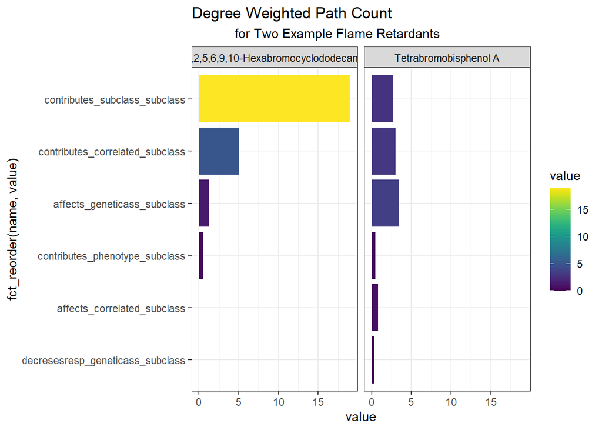

##### New query

```r
dwpc <- as_tibble(read_csv("C:/Users/Nyssa/Documents/GitHub/cautious-giggle/mml/20230126_mml_exemplar_use_ex_dwpc2.csv"))

colnames(dwpc)
```

```
##  [1] "`biolink:ChemicalEntity`"
##  [2] "`biolink:DiseaseOrPhenotypicFeature`"
##  [3] "P1:affects|correlated with|subclass of|"
##  [4] "P1:affects|genetic association|subclass of|"
##  [5] "P1:affects|regulates|subclass of|"
##  [6] "P1:affects|related to|subclass of|"
##  [7] "P1:decreases response to|genetic association|subclass of|"
##  [8] "P2:affects|correlated with|correlated with|"
##  [9] "P2:affects|directly physically interacts with|correlated with|"
## [10] "P2:affects|interacts with|correlated with|"
## [11] "P2:contributes to|correlated with|correlated with|"
## [12] "P2:contributes to|genetic association|correlated with|"
## [13] "P2:subclass of|subclass of|correlated with|"
```

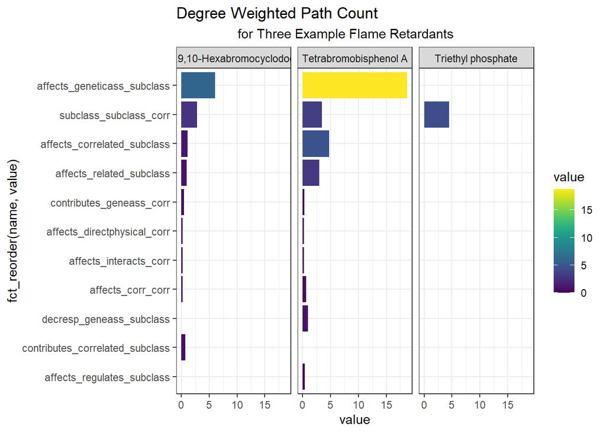

#### PCA

PCA is computed if unlabeled on the degree weighted path counts of start node entries.  
Therefore, this feature is best used to visualize many start node entries rather than the few presented here.

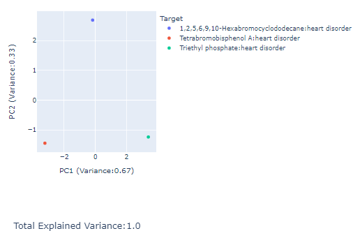

pca on flame retardant

# Fin

## Supporting documentation

Beasley, J.-M. T., Korn, D. R., Popov, K. I., Dumproff, R. L., Sessions, Z. L., Rath, M. K., Alves, V. M., Causey, K., Rua, D., Muratov, E. N., & Tropsha, A. (2022). Integrated approach to elucidate metal-implant related adverse outcome pathways. Regulatory Toxicology and Pharmacology, 136, 105277. https://doi.org/10.1016/j.yrtph.2022.105277

Bizon, C., Cox, S., Balhoff, J., Kebede, Y., Wang, P., Morton, K., Fecho, K., & Tropsha, A. (2019). ROBOKOP KG and KGB: Integrated Knowledge Graphs from Federated Sources. Journal of Chemical Information and Modeling, 59(12), 4968–4973. https://doi.org/10.1021/acs.jcim.9b00683

Exemplar landing page at https://www.exemplar.mml.unc.edu/